# ECON8022/4422 Macroeconomic Theory

#### Tutorial 9

Simon Mishricky

ANU email: u5009764@anu.edu.au

## Diamond Mortensen Pissarides

#### Aggregate state variable

Unemployment (rate), $u_t$ (Alternatively, by a change of variables, aggregate employment $N_t$)

#### Households

- Identical risk-neutral agents, each an element of $[0, 1]$
- Total discoutned utility, $\beta \in (0, 1)$: $$\sum_{t = 0}^{\infty}\beta^t C_t$$
- $C_t = w_t$. If the agent works $w_t$ is paid by the firm (wage income). If not, then $w_t = b$ (non-wage income/unemployment benefits)

#### Firms and production

- Firms, each an element of $[0, 1]$
- Post vacancy at per-period fixed cost $\kappa > 0$. There is free-entry to vacancy posting.
- Each firm hires at most one worker
- In a firm-worker match
  - The worker produces $A >0$ goods
  - Firm and worker bargain over real wage outcome $w_t$
- Firm's profit is $A - w_t >0$
- Each period, a match is destroyed with probability $s$

#### Decentralized labor matching market

- Current measures of unemployed and vacancies: $(u_t, v_t)$
- Market tightness: $\theta_t := v_t/u_t$
- (Reduced-form) *matching function* output total number of matches: $(u_t, v_t) \rightarrow M(u_t, v_t)$
  - Continuously differentiable and increasing in both inputs, and strictly concave
  - Homogeneous of degree one. Implies probability of matching for firm and worker, respectively, as

$$q_f(\theta_t) = \frac{M(u_t, v_t)}{v_t}, \quad q_w(\theta_t) := \theta_t q(\theta_t) = \frac{M(u_t, v_t)}{u_t}$$

## Exercise 0

Show that given the assumptions on $M$, that:

$$q'_f(\theta) < 0 \quad \text{and} \quad -1 < \frac{d \ln q_f(\theta)}{d \ln \theta} < 0$$

Explain in words what these mean

## Answer 0

Since $M$ is linearly homogenous, we can write

$$q_f( \theta) \equiv \frac{1}{v}M(u, v) = M(1/\theta, 1)$$

By inspection, $M$ is increasing in $u$ and $v$ individually. From the last line above, it is decreasing in $\theta$

Explicitly, we can derive:

$$q_f'(\theta) = - \frac{d M(1/ \theta, 1)}{d 1/\theta} \frac{1}{\theta^2} < 0$$

Thus

$$q'_f(\theta) < 0$$

A firm's probability of matching with a worker is decreasing in market tightness

- i.e. if there are more buyers relative to sellers in the labour market, each buyer (firm) has a harder time finding a worker
- The black-box matching mechanism $M$, which encapsulates market congestion externalities, implies this.

Within an $\epsilon$-neighbourhood of $\theta$, the percentage change in the firm's probability of making a match as a ratio to a percentage change in market tightness is just:

$$\epsilon_q(\theta):=\frac{d \ln q_f(\theta)}{d \ln \theta} = q'_f( \theta) \frac{\theta}{q_f( \theta)} = - \frac{dM(1/ \theta, 1)}{d 1/\theta} \frac{1}{\theta q_f( \theta)} < 0$$

Since this is a ratio of an infinitesimal rate of change in firm's matching probability relative to a given worker's matching probability, $|\epsilon_q( \theta)| < 1$.

Hence $\epsilon_q( \theta) \in (-1, 0)$

This unit-free object measures the *point elasticity of $q(\theta)$ with respect to $\theta$*,

- i.e. how sensitive is the firm's matching probability to market tightness (an endogenous object)

### Parametric instances of $M$

We require the matching function to have the following properties:

- Buyer: $q'_f( \theta) < 0$
- Seller: $q'_w( \theta) > 0$
- $\theta q_f( \theta) = q_w( \theta)$
- $q_w$, $q_f$ are uniformly bounded on $[0, 1]$

**Cobb-Douglas**. This was originally used by Pissarides (1985):

$ M(u,v) = \mu u^{\alpha}v^{1-\alpha}; \ \ \alpha \in (0,1), \mu > 0. $

- $\epsilon_{q}(\theta) = -\alpha$, is constant.
- Technically, the Cobb-Douglas function does not restrict $q_f(\cdot)$ to be uniformly bounded below $1$.
  - It is everywhere bounded below by $0$.
  - So in practice, we'll have to impose the requirement that $q_f(\theta) = \min\{ \mu \theta^{-\alpha}, 1\}$.

**Telegraph-line matching**.

- Cox and Miller (1965), *The Theory of Stochastic Processes*
- $q_w(\theta) = \left(\frac{\theta^{\rho}}{1+\theta^{\rho}}\right)^{\frac{1}{\rho}}$
- $q_w'(\theta) = \frac{1}{\theta}\frac{q_w(\theta)}{1+\theta^{\rho}}$

**Urn-ball matching**.

- $q_w(\theta) = 1 - \exp(-\theta)$
- $q_w'(\theta) = \exp(-\theta)$

#### Bathtub accounting process

- $u_t$ aggregate unemployment measure (also rate)

$$u_{t + 1} = s(1 - u_t) + \left[1 - \theta_t q_f( \theta_t) \right]u_t$$

- Next periods stock of unemployed is due to the flow from:
  - current stock of employed who gets separated from jobs at the end of this period, and
  - current stock of unemployed who don't get matched with firms

## Decision problems

Consider descriptions of:

- Firm's optimal behaviour given aggregate outcomes
- Housholds' optimal behaviour given aggregate outcomes
- How they interact through a terms-of-trade mechanism to determine allocative and pricing outcomes (Nash bargaining), and an adding up condition for the state of unemployment

### Firms

Given a wage outcome $w_t$, firm;s value of filling a vacancy this period:

$$J(u_t) = A - w_t + \beta \left[sV(u_{t + 1}) + (1 - s) J(u_{t + 1}) \right]\tag{J Bellman}$$

For a vacant firm this period, a firm's value is

$$V(u_t) = - \kappa + \beta \left[q_f( \theta_t)J(u_{t + 1}) + (1 - q_f(\theta_t))V(u_{t + 1}) \right] \tag{V Bellman}$$

### Households

Given wage outcome, the value to a current worker is

$$E(u_t) = w_t + \beta \left[s U(u_{t + 1}) + (1 - s)E(u_{t + 1}) \right] \tag{E Bellman}$$

A current unemployed agent's valuation is

$$U(u_t) = b + \beta \left[ q_w( \theta_t)E(u_{t + 1}) + (1 - q_w(\theta_t))U(u_{t + 1})\right] \tag{U Bellman}$$

### Wage Determination

Unlike Walrasian markets:

- Here we have decentralised trades
- There is no fictious Walrasian auctioneer
- Terms of trade is not a magical, un-modelled fixed point solution to some zero excess demand condition
- We need to be explicit on the process of trade -- i.e. model how terms of trade is pinned down
  - How about a bargaining process? Nash (1950) axiomatic bargaining
  - Or, Rubinstein and Wolinsky (1985) a non-cooperative sequential bargaining game interpretation of Nash

Here we'll take (generalised) representation of Nash's axiomatic bargaining problem.

The generalised Nash bargaining problem is represented by

$$\max_{w_t} \left[E(u_t) - U(u_t) \right]^{\eta} \left[J(u_t) - V(u_t) \right]^{1 - \eta}$$$$\text{s.t.}$$$$J(u_t) - V(u_t) \geq 0 \quad \text{and} \quad E(u_t) - U(u_t) \geq 0$$

### Solving for the optimality conditions

#### Worker firm optimality

Solving for the worker-firm optimality, we have

$$J(u_t) = A - w_t + \beta \left[sV(u_{t + 1}) + (1 - s) J(u_{t + 1}) \right]$$$$V(u_t) = - \kappa + \beta \left[q_f( \theta_t)J(u_{t + 1}) + (1 - q_f(\theta_t))V(u_{t + 1}) \right]$$

Free entry to vacancy posting means $V(u_t) = 0$ for all states and dates, the $V$ Bellman becomes

$$0 = - \kappa + \beta q_f( \theta_t)J(u_{t + 1})$$

Rearranging this, we get

$$J(u_{t + 1}) = \frac{\kappa}{\beta q_f( \theta_t)}$$

Substituting this into the $J$ Bellman, noting the free entry condition

$$\frac{\kappa}{\beta q(\theta_{t - 1})} = A - w_t + \frac{\beta (1 - s)\kappa}{\beta q_f( \theta_t)}$$

Rolling this one period forward and rearranging, we get the worker-firm optimality condition

$$\frac{\kappa}{q_f( \theta_t)} = \beta \left[A - w_{t + 1} + \frac{(1 - s)\kappa}{q_f( \theta_{t + 1})} \right]$$

#### Wage setting

Solving the generalised Nash bargaining problem, the first order condition is (noting the free entry condition)

$$\eta J(u_t) = (1 - \eta)\left[E(u_t) - U(u_t) \right]$$

Define total surplus by

$$S_t = J(u_t) + E(u_t) - U(u_t)$$

We need to define two things, firstly

$$\eta S_t = \eta J(u_t) + \eta E(u_t) - \eta U(u_t)$$

Using the first order condition we get

$$\eta S_t = (1 - \eta)\left[E(u_t) - U(u_t) \right] + \eta \left[E(u_t) - U(u_t)\right]$$$$\eta S_t = E(u_t) - U(u_t)$$

Similarly, we get

$$(1 - \eta) S_t = J(u_t) = \frac{\kappa}{\beta q_f( \theta_{t - 1})}\tag{1}$$

Now that we have these two equations we need find $S_t$

$$S_t = J(u_t) + E(u_t) - U(u_t)$$

Substituting the $J$, $E$ and $U$ Bellman equations (again noting the free entry conditions)

$$S_t = A - w_t + \beta(1 -s)J(u_{t + 1}) + \beta (1 - s)E(u_{t + 1}) + w_t + \beta s U(u_{t + 1}) + \beta(1- s)E(u_{t + 1}) - b - \beta \theta_t q_f( \theta_t)E(u_{t + 1}) - \beta \left(1 - \theta_t q_f( \theta_t \right)U(u_{t + 1})$$

This becomes

$$S_t = A - b + \beta(1 - s)S_{t + 1} - \beta \theta_t q_f(\theta_t) \left[E(u_t) - U(u_t) \right]$$$$ = A - b + \beta \left[1 - s - \theta_t q_f(\theta_t) \eta\right]S_{t + 1} \tag{2}$$

Where $\eta S_{t + 1} = E(u_{t + 1}) - U(u_{t + 1})$

Rolling $(1)$ one period forward and substituting it into $(2)$

$$ S_t = A - b + \beta \frac{\kappa\left[1 - s - \theta_t q_f(\theta_t)\eta\right]}{(1 - \eta) q_f( \theta_t)} \tag{3}$$

Now solving for $\eta S_{t}$

$$\eta S_t = E(u_t) - U(u_t)$$$$= w_t + \beta \left[sU(u_{t + 1}) + (1 - s)E(u_{t + 1}) \right] - b - \beta \left[\theta_t q_f( \theta_t)E(u_{t + 1}) + \left( 1 - \theta_t q_f( \theta_t)\right)U(u_{t + 1}) \right]$$$$= w_t - b + \beta \left[sU(u_{t + 1}) + E(u_{t + 1}) - sE(u_{t + 1}) - \theta_t q_f( \theta_t)E(u_{t + 1}) - U(u_{t + 1}) + \theta_t q_f( \theta_t)U(u_{t + 1}) \right]$$$$ = w_t - b + \beta \left[\eta S_{t + 1} - s \eta S_{t + 1} - \theta_t q_f( \theta_t) \eta S_{t + 1} \right]$$

And thus we get

$$\eta S_t = w_t -b + \beta \left[1 - s - \theta_t q_f( \theta_t) \right]\eta S_{t + 1}\tag{4}$$

Substituting $S_t$ for $(3)$ and $S_{t + 1}$ for $(1)$ (rolled forward one period) into $(4)$

$$\eta \left(A - b + \beta \frac{\kappa\left[1 - s - \theta_t q_f(\theta_t)\eta\right]}{(1 - \eta) q_f( \theta_t)} \right) = w_t -b + \beta \frac{\eta \kappa \left[1 - s - \theta_t q_f( \theta_t) \right]}{\beta (1 - \eta) q_f( \theta_t)}$$

Solving for $w_t$

$$w_t = \eta A + (1 - \eta)b + \frac{\eta \kappa \left[1 - s - \theta_t q_f( \theta_t) \eta \right]}{(1 - \eta)q_f( \theta_t)} - \frac{\eta \kappa \left[1 - s - \theta_t q_f( \theta_t) \right]}{(1 - \eta)q_f( \theta_t)}$$

This becomes

$$w_t = \eta A + (1 - \eta)b + \eta \kappa \theta_t$$

And thus we get the wage equation

$$w_t = \eta(A + \kappa \theta_t) + (1 - \eta)b$$

#### Ljungvist and Sargent solution (Steady state equilibrium)

If we are only concerned about the steady state equilibrium, we can solve the problem in the following way, (note we drop the $t$ subscript)

Solving the Nash bargaining problem, the first order condition is

$$\eta J(u) = (1 - \eta)\left[E(u) - U(u) \right]$$

At the steady state, and with the free entry condition

$$J(u) = A - w + \beta(1 - s)J(u)$$

Rearranging this,

$$J(u) = \frac{A - w}{1 - \beta(1 - s)}$$

Since $\beta = \frac{1}{1 + r}$, we have

$$J(u) = \frac{\left(A - w \right)\left(1 + r \right)}{r + s}$$

We also have

$$E(u) = w + \beta \left[sU(u) + (1 - s)E(u) \right]$$

Rearranging, we get

$$E(u) = \frac{w + \beta s U(u)}{1 - \beta (1 - s)} = \frac{\left(w + \beta s U(u) \right) \left(1 + r \right)}{r + s}$$$$E(u) - U(u) = \frac{w(1 + r)}{r + s} + \frac{sU(u)}{r + s} - U(u)$$

This becomes

$$E(u) - U(u) = \frac{w(1 + r) - rU(u)}{r + s}$$

Substituting this and $J(u)$ into the first order condition

$$\frac{\eta (A - w)(1 + r)}{r + s} = \frac{(1 - \eta)}{r + s}\left[w(1 + r) - rU(u) \right]$$

Rearranging this we get the wage equation

$$w = \frac{r U(u)}{1 + r} + \eta \left(A - \frac{r U(u)}{1 + r} \right)$$

To solve for $\frac{rU(u)}{1 + r}$ we need

$$U(u) = b + \beta \left[\theta q_f(\theta)E(u) + \left(1 - \theta q_f(\theta) \right)U(u) \right]$$

Remembering that $q_w(\theta) = \theta q_f(\theta)$, now rearranging for $E(u)$,

$$E(u) = \frac{\left(1 - \beta \left(1 - \theta q_f(\theta)\right) \right)U(u) - b}{\beta \theta q_f(\theta)}$$

Subtracting $U(u)$ from both sides we get

$$E(u) - U(u) = \frac{(1 - \beta) + \beta \theta q_f( \theta)U(u) - b - \beta \theta q_f( \theta)U(u)}{\beta \theta q_f( \theta)}$$

Which is

$$E(u) - U(u) = \frac{(1 - \beta)U(u) - b}{\beta \theta q_f( \theta)}$$

Substituting this and

$$J(u) = \frac{\kappa}{\beta q_f( \theta)}$$

Into the first order condition, we get

$$\frac{\eta \kappa}{\beta q_f( \theta)} = \frac{(1 - \eta) \left[ (1 - \beta) U(u) - b\right]}{\beta \theta q_f( \theta)}$$

Noting that $(1 - \beta) = \frac{r}{r + s}$, we can rearrange the above equation to get

$$\frac{r U(u)}{r + s} = b + \frac{\eta \kappa \theta}{1 - \eta}$$

Substituting this into the wage equation, we get

$$w = b + \frac{\eta \kappa \theta}{1 - \eta} + \eta \left(A - b - \frac{\eta \kappa \theta}{1 - \eta} \right)$$$$= (1 - \eta) \left[b + \frac{\eta \kappa \theta}{1 - \eta} \right] + \eta A$$$$= (1 - \eta)b + \eta \kappa \theta + \eta A$$

And thus we have the wage determination equation

$$w = \eta(A + \kappa \theta) + ( 1- \eta)b$$

### Recursive decentralised equilibrium

We need $A > b$ for a well-defined equilibrium

A recursive, decentralised equilibrium is a sequence $\{u_{t + 1}, \theta_{t}, w_t \}_{t = 0}^{\infty}$ satisfying:

1. Worker and firm optimality,

$$ \frac{\kappa}{q_f( \theta_t)} = \beta \left[A - w_{t + 1} + \frac{(1 - s) \kappa}{q_f( \theta_{t + 1})} \right]$$

1. Employment stock-flow consistency, given $u_0$,

$$u_{t + 1} = s(1 - u_t) + [1 - q_w(\theta_t)]u_t$$

1. Nash bargaining wage-setting solution,

$$w_t = \eta\left(A + \kappa \theta_t \right) + (1 - \eta)b$$

### Steady state equilibrium

A steady-state equilibrium is a triple $\{u_{ss}, \theta_{ss}, w_{ss} \}$, satisfying the following conditions

1. *Job creation*

$$\frac{\kappa}{q_f( \theta_{ss})}\left[1 - \beta(1 - s) \right] = \beta (A - w_{ss})$$

1. *Bathtub transition*

$$s(1 - u_{ss}) = q_w(\theta_{ss})u_{ss}$$

1. *Wage setting*

$$w_{ss} = \eta(A + \kappa \theta_{ss}) + (1 - \eta)b$$

## Exercise 1

Provide an economic interpretation for the steady state equilibrium conditions. That is, explain in words what are the forces at work which maintain that long-run equilibrium

## Answer 1

Starting with the equilibrium wage, we can see that the steady state wage is a convex combination of the outside option $b$ and their share net gain of the firm $(A + \kappa \theta)$. The weightings are determined by the workers bargaining power $\eta$

Moving to the Job creation equation, as the equilibrium wage $w$ increases the value of filling a job decreases, given an exogenous job destruction rate $s$. This implies that $\theta$ decreases. This means that $q_w(\theta)$ decreases, and this leads to an increase in $u$ as seen from the bathtub transition equation. This equilibrates however, since a decrease in $\theta$ leads to a corresponding decrease in $w$

## Exercise 2

Consider the steady state equilibrium above

1. What happens to the steady state unemployment rate if $b$ is higher?
2. What happens to the steady state unemployment rate if $s$ is higher?
3. What happens to the steady state unemployment rate if $A$ is higher?
4. What happens to the steady state unemployment rate if $\kappa$ is higher?

*Explain* your conclusions using appropriate equations and figures

## Answer 2

To solve what happens to steady state unemployment when $b$ is higher, first we have

$$\frac{\kappa}{q_f( \theta_{ss})}\left[ 1 - \beta(1 - s) \right] = \beta(A - w_{ss})$$$$s(1 - u_{ss}) = q_w( \theta_{ss})u_{ss}$$$$w_{ss} = \eta(A + \kappa \theta_{ss}) + (1 - \eta)b$$

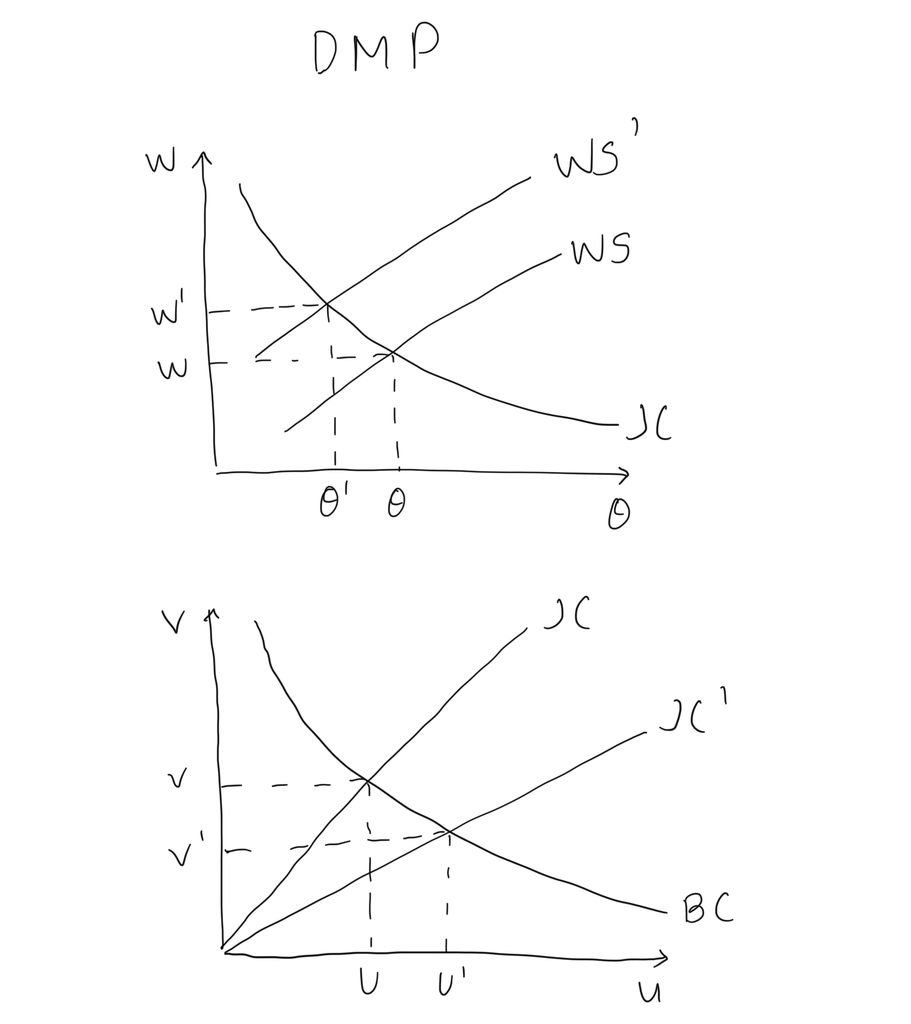

To solve what happens to steady state unemployment when $s$ is higher, first we have from the Bathtub equation

$$u_{ss} = \frac{s}{s + \theta_{ss}q_f(\theta_{ss})}$$$$\frac{du_{ss}}{ds} = \frac{(s + \theta_{ss}q_f(\theta_{ss})) - s}{(s + \theta_{ss}q_f(\theta_{ss}))^2}$$

Thus we have

$$\frac{du_{ss}}{ds} = \frac{\theta_{ss}q_f( \theta_{ss})}{(s + \theta_{ss}q_f(\theta_{ss}))^2} > 0$$

The last two are left as an exercise

### Log-linearised job creation

Log-linearising the job creation equation with the wage setting equation, we start with

$$\frac{\kappa}{q_f(\theta_t)} = \beta \left[A - w_{t + 1} + \frac{(1 - s)\kappa}{q_f( \theta_{t + 1})} \right]$$$$w_t = \eta(A + \kappa \theta_t) + (1 - \eta)b$$

Rolling the wage equation one period forward, and substituting it into the job creation equation, we get

$$\frac{\kappa}{q_f(\theta_t)} = \beta \left[A - \eta(A + \kappa \theta_{t + 1}) - (1 - \eta)b + \frac{(1 - s)\kappa}{q_f( \theta_{t + 1})} \right]$$

Expanding this out explicitly, and dividing by $\kappa$

$$\frac{1}{q_f( \theta_t) } = \frac{\beta A}{\kappa} - \frac{\beta \eta A}{\kappa} - \frac{(1 - \eta) b \beta}{\kappa} - \beta \eta \theta_{t + 1} + \frac{\beta ( 1 - s)}{q_f( \theta_{t + 1})}\tag{1}$$

Log-linearising $\frac{1}{q_f( \theta_t) }$, we get

$$\frac{1}{q_f( \theta_t)} = \frac{1}{q_f( \theta_{ss})} - \frac{1}{\left(q_f( \theta_{ss}) \right)^2}q'_f(\theta_{ss})(\theta_t - \theta_{ss})$$

We also know that

$$\epsilon_q( \theta_{ss}) = q'_f( \theta_{ss}) \frac{\theta_{ss}}{q_f(\theta_{ss})} \implies q'_f( \theta_{ss}) = \frac{\epsilon_q( \theta_{ss})q_f( \theta_{ss})}{\theta_{ss}}$$

Thus we get

$$\frac{1}{q_f( \theta_t)} = \frac{1}{q_f( \theta_{ss})} - \frac{\epsilon_q(\theta_{ss})}{\theta_{ss}q_f( \theta_{ss})}(\theta_t - \theta_{ss})\tag{2}$$

Similarly at time $t + 1$, we have that

$$\frac{1}{q_f( \theta_{t + 1})} = \frac{1}{q_f( \theta_{ss})} - \frac{\epsilon_q(\theta_{ss})}{\theta_{ss}q_f( \theta_{ss})}(\theta_{t + 1} - \theta_{ss})\tag{3}$$

Now log-linearising $\eta \beta \theta_{t + 1}$

$$\eta \beta \theta_{t + 1} = \eta \beta \theta_{ss} + \eta \beta (\theta_{t + 1} - \theta_{ss})\tag{4}$$

Now substituting $(2)$, $(3)$ and $(4)$ into $(1)$

$$\frac{1}{q_f( \theta_{ss})} - \frac{\epsilon_q(\theta_{ss})}{\theta_{ss}q_f( \theta_{ss})}(\theta_{t} - \theta_{ss}) = \left[\frac{\beta A}{\kappa} - \frac{\beta \eta A}{\kappa} - \frac{(1 - \eta) b \beta}{\kappa} \right] - \beta \eta \theta_{ss} - \beta \eta (\theta_{t + 1} - \theta_{ss}) + \beta(1 - s)\left[\frac{1}{q_f( \theta_{ss})} - \frac{\epsilon_q(\theta_{ss})}{\theta_{ss}q_f( \theta_{ss})}(\theta_{t + 1} - \theta_{ss}) \right]$$

Rearranging

$$- \frac{\epsilon_q(\theta_{ss})}{\theta_{ss}q_f( \theta_{ss})}(\theta_{t} - \theta_{ss}) = \left[\frac{\beta A}{\kappa} - \frac{\beta \eta A}{\kappa} - \frac{(1 - \eta) b \beta}{\kappa} - \beta \eta \theta_{ss} + \frac{\beta(1 - s)}{q_f( \theta_{ss})} - \frac{1}{q_f( \theta_{ss})}\right] - \beta \eta (\theta_{t + 1} - \theta_{ss}) - \frac{\beta(1 - s)\epsilon_q(\theta_{ss})}{\theta_{ss}q_f( \theta_{ss})}(\theta_{t + 1} - \theta_{ss})$$

We know from the steady state job creation equation and wage setting equation that

$$\frac{\kappa\left[1 - \beta(1- s) \right]}{q_f(\theta_{ss})} = \beta\left[A - \eta(A + \kappa \theta_{ss}) - (1 - \eta)b \right]$$

Rearranging and expanding

$$\frac{\beta A}{\kappa} - \frac{\beta \eta A}{\kappa} - \frac{(1 - \eta) b \beta}{\kappa} - \beta \eta \theta_{ss} + \frac{\beta(1 - s)}{q_f( \theta_{ss})} - \frac{1}{q_f( \theta_{ss})} = 0$$

Therefore our equation becomes

$$- \frac{\epsilon_q(\theta_{ss})}{\theta_{ss}q_f( \theta_{ss})}(\theta_{t} - \theta_{ss}) =\left[ - \beta \eta - \frac{\beta (1 - s)\epsilon_q(\theta_{ss})}{\theta_{ss}q_f( \theta_{ss})}\right](\theta_{t + 1} - \theta_{ss})$$

Therefore our log-linearised solution becomes

$$(\theta_t - \theta_{ss}) \approx \beta \left[1 - s + \eta \frac{\theta_{ss}q_f( \theta_{ss})}{\epsilon_q(\theta_{ss})} \right](\theta_{t + 1} - \theta_{ss})$$

So unlike backward-looking difference equations, this equation is forward looking. $\theta_t$ has no initial condition. So we solve it forward by forward substitution

For a well-defined (first-order accurate) dynamic equilibrium, the forward solution must be convergent, or must not explode, this requires

$$\bigg{|}\bigg{|}\beta \left[1 - s + \eta \frac{\theta_{ss}q_f( \theta_{ss})}{\epsilon_q(\theta_{ss})} \right]\bigg{|}\bigg{|} < 1$$

### Log-linearised bathtub equation

Log-linearising the employment stock-flow consistency, we start with

$$u_{t + 1} = s(1 - u_t) + (1 - \theta_t q_f(\theta_t))u_t$$

Expanding this and simplifying

$$u_{t + 1} = s + \left[1 - s - \theta_t q_f( \theta_t) \right]u_t$$

Using a first order taylor approximation on the last part of the above equation

$$\left[1 - s - \theta_t q_f( \theta_t) \right]u_t = \left[1 - s - \theta_{ss} q_f( \theta_{ss}) \right]u_{ss} + \left[1 - s - q_w(\theta_{ss}) \right](u_t - u_{ss}) - u_{ss} \left[\theta_{ss}q'_f( \theta_{ss}) + q_f(\theta_{ss}) \right](\theta_t - \theta_{ss})$$

Substituting this into the above equation

$$u_{t + 1} \approx s + \left[1 - s - \theta_{ss} q_f( \theta_{ss}) \right]u_{ss} + \left[1 - s - q_w(\theta_{ss}) \right](u_t - u_{ss}) - u_{ss} \left[\theta_{ss}q'_f( \theta_{ss}) + q_f(\theta_{ss}) \right](\theta_t - \theta_{ss})$$

Which becomes

$$u_{t + 1} - u_{ss} \approx s(1 - u_{ss}) - \theta_{ss}q_f( \theta_{ss})u_{ss} + \left[1 - s - q_w(\theta_{ss}) \right](u_t - u_{ss}) - u_{ss} \left[\theta_{ss}q'_f( \theta_{ss}) + q_f(\theta_{ss}) \right](\theta_t - \theta_{ss})$$

We know that $s(1 - u_{ss}) - \theta_{ss}q_f( \theta_{ss})u_{ss} = 0$ from the steady state bathtub accounting process, and we also know

$$\epsilon_q( \theta_{ss}) = q'_f( \theta_{ss}) \frac{\theta_{ss}}{q_f(\theta_{ss})} \implies q'_f( \theta_{ss}) = \frac{\epsilon_q( \theta_{ss})q_f( \theta_{ss})}{\theta_{ss}}$$

Thus we have

$$u_{t + 1} - u_{ss} \approx \left[1 - s - q_w(\theta_{ss}) \right](u_t - u_{ss}) - u_{ss}q_f( \theta_{ss}) \left[1 + \epsilon_q( \theta_{ss})\right](\theta_t - \theta_{ss})$$

### Exercise 3

Assume $\vert \beta \left[1-s+\eta {\theta_{ss}q_{f}(\theta_{ss})}/{\epsilon_{q}(\theta_{ss})}\right] \vert < 1$ holds.

Show that the linearized approximate equilibrium system is saddle-point stable locally, i.e., around a small neighborhood of the steady state equilibrium point $(u_{ss}, \theta_{ss})$.

### Answer 3

We have the following equations

$$(\theta_t - \theta_{ss}) \approx \beta \left[1 - s + \eta \frac{\theta_{ss}q_f( \theta_{ss})}{\epsilon_q(\theta_{ss})} \right](\theta_{t + 1} - \theta_{ss})$$$$u_{t + 1} - u_{ss} \approx \left[1 - s - q_w(\theta_{ss}) \right](u_t - u_{ss}) - u_{ss}q_f( \theta_{ss}) \left[1 + \epsilon_q( \theta_{ss})\right](\theta_t - \theta_{ss})$$

Define $d\theta_{t + 1} = \theta_{t + 1} - \theta_{ss}$ and $du_{t + 1} = u_{t + 1} - u_{ss}$, we can write the above system as

$$\begin{bmatrix}d\theta_{t + 1} \\ du_{t + 1} \end{bmatrix} = \begin{bmatrix}a_{11} & 0\\a_{21} & a_{22}\end{bmatrix}\begin{bmatrix} d\theta_{t} \\ du_{t}\end{bmatrix}$$

Where: $$a_{11} = \frac{1}{\beta \left[1-s+\eta {\theta_{ss}q_{f}(\theta_{ss})}/{\epsilon_{q}(\theta_{ss})}\right]}$$

$$a_{21} = - u_{ss}q_f( \theta_{ss}) \left[1 + \epsilon_q( \theta_{ss} )\right]$$$$a_{22} = 1 - s - q_w(\theta_{ss})$$

This system has a unique solution when the number of eigenvalues of the matrix outside the unit circle is equal to the number of non-predetermined variables. In the present case, $u_t$ is predetermined, and thus the number of non-predetermined variables is one (since $\theta_t$ is a the only non-predetermined variable. This is also known as saddle point stability. We can see from the above equations that the steady state is a solution, but is it unique?

The eigenvalues of this matrix are given by

$$\lambda^2 - (a_{11} + a_{22})\lambda + a_{11}a_{22} = 0$$

Since $a_{11} >1$ and $a_{22} \in (-1, 1)$ we can show that one eigenvalue is outside the unit circle. Therefore the system is saddle point stable and the solution is the steady state.

```python
import numpy as np
import scipy.optimize as opt
import matplotlib.pyplot as plt
```

```python
# Parameters (Hagedorn and Manovskii)
A = 1.0                  # Labour productivity
b = 0.955                # Outside option: Non-labour income
β = 0.99**(1.0 / 12.0)   # Discount factor (monthly frequency)
η = 0.052                # Workers bargaining power
s = 0.081                # One-period job-match destruction probability
κ = 0.11                 # Per-period vacancy posting fixed cost

ϕ = 3                    # Arbitrary value for Cobb-Douglas production

ψ = 2                    # Disutility of Labor Coefficient

# Alternative matching function parameters
ρ = 0.407               # Telegraph-line matching

α = 0.27                # Cobb-Douglas unemployment share
μ = 1.0                 # Cobb-Douglas efficiency scale

δ = 1.0                 # Urn-ball matching share of evaporated buyers

# Sorting parameters into dictionary
parameters = {"Labour productivity": A,
              "Non-labour income": b,
              "Discount factor": β,
              "Worker bargaining power": η,
              "Job destruction rate": s,
              "Vacancy posting cost": κ,
              "Cobb-Douglas exponent": ϕ,
              "Disutility exponent": ψ,
              "Unemployment share -- Cobb-Douglas": α,
              "Efficiency scale -- Cobb-Douglas": μ,
              "Unemployment share -- Telegraph": ρ,
              "Dissipation -- Urn-ball": δ}
```

```python
# Functions
def q(θ, parameters, matching_type="Telegraph"):
    '''This function given the probabilities of firms matching
    with workers, and workers matching with firms, respectively,
    given a market tightness θ'''

    # Firm's matching probability with a worker
    if matching_type == "Cobb-Douglas":
        α = parameters["Unemployment share -- Cobb-Douglas"]
        μ = parameters["Efficiency scale -- Cobb-Douglas"]

        q_f = min(μ * θ**(- α), 1.0 - 1e-4)

    elif matching_type == "Telegraph":
        ρ = parameters["Unemployment share -- Telegraph"]

        q_f = 1.0 / ((1.0 + θ**ρ)**(1.0 / ρ))

    elif matching_type == "Urn-ball":
        δ = parameters["Dissipation -- Urn-ball"]

        q_f = (1.0 - np.exp(- δ * θ)) / θ

    # Worker's matching probability with a firm
    q_w = θ * q_f

    return q_f, q_w

def ϵ(θ, parameters, matching_type="Telegraph"):
    '''Point elasticity of firm's matching probability given
    market tightness'''

    q_f = q(θ, parameters, matching_type)[0]

    if matching_type == "Cobb-Douglas":
        α = parameters["Unemployment share -- Cobb-Douglas"]
        μ = parameters["Efficiency scale -- Cobb-Douglas"]

        qf_ϵ = - α * μ * θ**(- α - 1.0)

    elif matching_type == "Telegraph":
        ρ = parameters["Unemployment share -- Telegraph"]

        qf_ϵ = - (θ**(ρ - 1.0)) / ((1.0 + θ**ρ)**(1.0 / ρ + 1))

    elif matching_type == "Urn-ball":
        δ = parameters["Dissipation -- Urn-ball"]

        qf_ϵ = ((1.0 + (δ * θ)) * np.exp(- δ * θ) - 1.0) / (θ**2.0)

    return (θ * qf_ϵ) / q_f

def w(θ, parameters):
    '''This function solve for the Nash bargaining solution'''

    # Extract parameters
    A = parameters["Labour productivity"]
    b = parameters["Non-labour income"]
    η = parameters["Worker bargaining power"]
    κ = parameters["Vacancy posting cost"]

    return (η * (A + (κ * θ_ss))) + ((1 - η) * b)

def u_next_period(θ, u, parameters, matching_type="Telegraph"):
    '''This is the bathtub model of unemployment'''

    s = parameters["Job destruction rate"]
    qf = q(θ, parameters, matching_type)[0]

    u_plus = s * (1 - u) + (1.0 - (θ * qf)) * u

    return u_plus

def θ_steady_state(parameters, matching_type="Telegraph"):
    '''This function solves for the steady state market tightness'''

    # Extract parameters
    A = parameters["Labour productivity"]
    b = parameters["Non-labour income"]
    β = parameters["Discount factor"]
    η = parameters["Worker bargaining power"]
    s = parameters["Job destruction rate"]
    κ = parameters["Vacancy posting cost"]

    objective = lambda θ: (κ / q(θ, parameters, matching_type)[0]) - β * ((1 - η) * (A - b) - (η * κ * θ)) - β * ((1 - s) * (κ / q(θ, parameters, matching_type)[0]))

    θ_ss = opt.root(objective, 1e-3, method='lm', options={'ftol': 1e-10}).x

    return θ_ss

def u_steady_state(θ, parameters, matching_type="Telegraph"):
    '''This function solves for the steady state unemployment'''

    u_ss = s / (s + (θ * q(θ, parameters, matching_type)[0]))

    return u_ss

def vector_field(U, V, parameters, matching_type="Telegraph"):

    U = U.flatten()
    V = V.flatten()

    # Extract parameters
    β = parameters["Discount factor"]
    η = parameters["Worker bargaining power"]
    s = parameters["Job destruction rate"]
    κ = parameters["Vacancy posting cost"]

    # Storage space
    ui = np.zeros(U.size)
    vi = np.zeros(V.size)

    θ_ss = θ_steady_state(parameters, matching_type)

    qw_ss = q(θ_ss, parameters, matching_type)[1]

    for i, (u, θ) in enumerate(zip(U, V)):

        θ_next = ((θ - θ_ss) / (β * (1 - s + (η * (qw_ss / ϵ(θ_ss, parameters, matching_type)))))) + θ_ss

        u_next = u_next_period(θ, u, parameters, matching_type)

        δu = u_next - u
        δθ = θ_next - θ

        ui[i] = δu
        vi[i] = δθ

    return ui, vi

def θ_zeros(x, parameters, matching_type="Telegraph"):

    # Storage space
    θ = np.zeros(x.size)

    for i, u in enumerate(x):

        objective = lambda θ: (q(θ, parameters, matching_type)[1] * u) - (s * (1 - u))
        θ[i] = opt.brentq(objective, 0.001, 10.0)

    return θ
```

```python
θ_ss = θ_steady_state(parameters)
u_ss = u_steady_state(θ_ss, parameters)

θ_ss, u_ss
```

```
(array([0.61242606]), array([0.36519947]))
```

```python
test = 1 - s + η * θ_ss * (q(θ_ss, parameters)[0] / ϵ(θ_ss, parameters))

test < 1.0
```

```
array([ True])
```

```python
N = 20

xmin, xmax = u_ss * 0.85, u_ss * 1.1
ymin, ymax = θ_ss * 0.5, θ_ss * 1.5

x = np.linspace(xmin, xmax, N)
y = np.linspace(ymin, ymax, N)

U, V = np.meshgrid(x,y)

ui, vj = vector_field(U, V, parameters)

θ = θ_zeros(x, parameters)
```

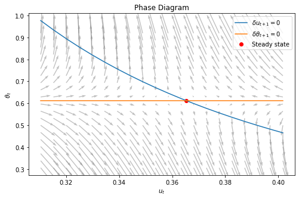

```python
fig, ax = plt.subplots(figsize=(8, 5))

ax.set_title('Phase Diagram')
ax.set_ylabel('$θ_t$')
ax.set_xlabel('$u_t$')
ax.plot(x, θ, label="$δu_{t + 1} = 0$")
ax.plot(x, np.tile(θ_ss, x.shape), label="$δθ_{t + 1} = 0$")
ax.scatter(u_ss, θ_ss, color="red", label="Steady state")
ax.quiver(U, V, ui, vj,
            color="grey",
            alpha=0.5,
            scale=0.05,
            scale_units='inches')
plt.legend()
plt.show()
```

### Exercise 4

Suppose the economy at date $t=0$ was perturbed away from its steady state equilibrium, such that $u_{0} > u_{ss}$.

Compute the response of the model in terms of its dynamic equilibrium outcome.

### Answer 4

```python
def simulate(T, parameters):

    # Initialise the steady state
    θ_ss = θ_steady_state(parameters)

    # Storage space
    u_series = np.zeros(T)
    v_series = np.zeros(T)
    w_series = np.zeros(T)
    θ_series = np.zeros(T)

    # Steady state series
    u_s = u_ss * np.ones(T)
    v_s = θ_ss * u_ss * np.ones(T)
    w_s = w(θ_ss, parameters) * np.ones(T)
    θ_s = θ_ss * np.ones(T)

    # Initial values
    θ_series[0] = θ_ss
    u_series[0] = 1 + u_ss
    v_series[0] = θ_ss * u_series[0]
    w_series[0] = w(θ_ss, parameters)

    for t in range(T - 1):
        θ_series[t + 1] = θ_ss
        u_series[t + 1] = u_next_period(θ_ss, u_series[t], parameters)
        v_series[t + 1] = θ_ss * u_series[t + 1]
        w_series[t + 1] = w(θ_ss, parameters)

    return np.asarray([[θ_series],[u_series],[v_series],[w_series]]), np.asarray([[θ_s],[u_s],[v_s],[w_s]])
```

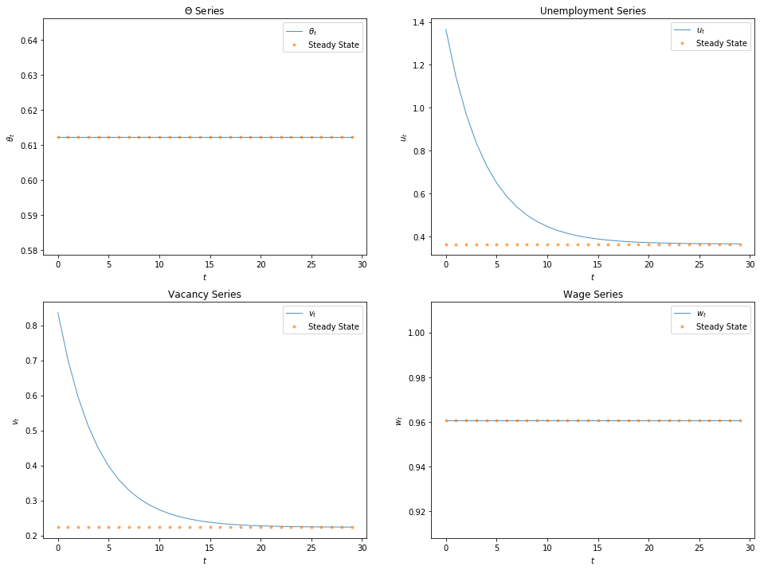

```python
T = 30

time_series, steady_series = simulate(T, parameters)

titles = np.array(['$Θ$ Series',
                   'Unemployment Series',
                   'Vacancy Series',
                   'Wage Series'])

labels = np.array(['$θ_t$',
                   '$u_t$',
                   '$v_t$',
                   '$w_t$'])

fig, axes = plt.subplots(2, 2, figsize=(16, 12))
axes = axes.flatten()

for j, k in enumerate(titles):
    axes[j].set_title(str(k))
    axes[j].set_ylabel(str(labels[j]))
    axes[j].set_xlabel('$t$')
    t_series = time_series[j].flatten()
    ss_series = steady_series[j].flatten()
    axes[j].plot(t_series, lw=1, alpha=0.8, label=str(labels[j]))
    axes[j].plot(ss_series, '.', lw=1, alpha=0.6, label="Steady State")
    axes[j].legend()

plt.show()
```

### Exercise 5

Consider now the same perfect foresight model but now there is a measure-one, infinite set of firms. Each firm $j \in [0,1]$ hires total labor $N_{t}^{j}$ each period producing output using production function: $Y_{t}^{j} = \left(AN_{t}^{j}\right)^{\phi}$, where $\phi \in (0,1)$. The representative household (for a measure-one continuum of households) now has preference $\sum_{t=0}^{\infty}\beta^{t}\left[ C_{t} - N_{t}^{1+\psi}/(1+\psi) \right]$ where $\psi > 0$.

Interpretation:

- Each member $i \in [0,1]$ seeks to get matched with a firm $j \in [0,1]$.
- Each member dislikes work. Assume disutility of working for member $i$ is $ i^{\psi}$.
- The aggregate or representative household disutility of work is thus $$ \int_{0}^{N_{t}} i^{\psi}di = \frac{N_{t}^{1+\psi}}{1+\psi}, $$

In equilibrium, aggregate employment across all firms is consistent with total household supply $N_{t} = \int_{0}^{1}N_{t}^{j}\text{d}j$.

This another simplified and deterministic special case of the production economy (with labor and capital) of Merz (1995), Andolfatto (1996) and den Haan, Ramey and Watson (2000). (See Miao, Chapter 18.3.)

Redo the questions in the last exercise. Show that now, the solution will be an *equilibrium*-determined market tightness function $N_{t} = \theta^{\star}(N_{t})$ solving the JC-Euler equation, a static, wage function $N_{t} \mapsto w^{\star}(N_{t})$ satisfying the equilibrium wage-setting equation, and a bathtub law of motion for the state variable $N_{t}$ respecting the stock-flow accounting of individuals in the system.

You don't have to compute the solution. If you do, experiment with some number $\psi > 0$ for your computer example. (At this stage, you are not yet ready to statistically calibrate the model to empirical statistics.)

### Answer 5

#### Households

- Identical risk-neutral agents, each an element of $[0, 1]$
- Total discoutned utility, $\beta \in (0, 1)$:
- $C_t = w_t$. If the agent works $w_t$ is paid by the firm (wage income). If not, then $w_t = b$ (non-wage income/unemployment benefits)

$$ \sum_{t = 0}^{\infty} \beta^t \left[C_t - N_t^{\psi}/ ( 1 + \psi) \right]$$$$\text{s.t.}$$$$C_t = w_t N_t + b(1 - N_t)$$$$N_{t + 1} = (1 - s)N_t + q_w(\theta_t)(1 - N_t)$$

We may write the households's problem as:

$$V_t(N_t) = C_t - \frac{N_t^{1 + \psi}}{1 + \psi} + \beta V(N_{t + 1})$$$$\text{s.t.}$$$$C_t = w_t N_t + b(1 - N_t)$$$$N_{t + 1} = (1 - s)N_t + q_w(\theta_t)(1 - N_t)$$

By the envelope condition,

$$S^H_t = \frac{dV(N_t)}{dN_t} = (w_t - b) - N_t^{\psi} + \frac{dN_{t + 1}}{dN_t} \beta \left[\frac{dV(N_{t + 1})}{dN_{t + 1}} \right]$$

Which becomes: $$S^H_t = (w_t - b) - N_t^{\psi} + (1 - s - \theta_t q_f(\theta_t)) \beta S^H_{t + 1}$$

#### Firms

- Firms, each an element of $[0,1]$
- Post vacancy at per-period cost $\kappa > 0$. There is free-entry to vacancy posting.
- Each firm hires $N_t^j$ workers
- Firm's profit per period is $\left(A N_t^j\right)^{\phi} -w_t N_t^j - v_t^j \kappa >0$
- Each period, a match is destroyed with probability $s$:
- The bathtub accounting process writting in terms of $N$ becomes: $$ N^j_{t + 1} = (1 - s)N_t^j + q_f(\theta_t) v_t^j$$

Since $N_t = 1 - u_t$

Thus the firms problem becomes:

$$\max_{\left\{N_t^j, v_t^j \right\}} \sum_{t = 0}^{\infty} \beta^t \left(\left(AN_t^j \right)^{\phi} - w_t N_t^j -v_t^j \kappa \right)$$$$\text{s.t.}$$$$N^j_{t + 1} = (1 - s)N_t^j + q_f(\theta_t)v_t^j$$

The first order conditions of this problem are:

$$N_t^j: \quad \phi A\left(AN_t^j\right)^{\phi - 1} - w_t + \mu_t(1 - s) - \mu_{t - 1} \beta^{-1} = 0$$$$v_t^j: \quad - \kappa + \mu_t q_f(\theta_t) = 0$$

Combining these equations, rolling one period forward and rearranging we get:

$$\frac{\kappa}{q_f(\theta_t)} = \beta \left[\phi A\left(AN_{t + 1}^j\right)^{\phi - 1} - w_{t + 1} + \frac{(1 - s)\kappa}{q_f(\theta_{t + 1})} \right]$$

We may write the firms problem as

$$J(N_t^j) = \max_{v_t^j} \left\{\left(AN_t^j \right)^{\phi} - w_t N_t^j -v_t^j \kappa + \beta J(N_{t + 1}^j) \right\}$$$$\text{s.t.}$$$$N^j_{t + 1} = (1 - s)N_t^j + q_f(\theta_t)v_t^j$$

By the envelope condition:

$$S^F_t = \frac{dJ(N^j_t)}{dN^j_t} = \phi A \left( A N_t^j\right)^{\phi -1} - w_t + \frac{dN_{t + 1}^j}{dN^j_t}\beta \frac{dJ(N_{t + 1}^j)}{dN_{t + 1}^j}$$

Which becomes:

$$ S^F_t = \phi A \left(A N_t^j\right)^{\phi -1} - w_t + (1 - s)\beta S^F_{t + 1}$$

Taking the first order conditions of $J(N_t^j)$, we get

$$- \kappa + \beta \frac{dJ(N^j_{t + 1})}{dN_{t + 1}^j}q_f (\theta_t) = 0$$

Rearranging this we get:

$$S_{t + 1}^F = \frac{dJ(N^j_{t + 1})}{dN_{t + 1}^j} = \frac{\kappa}{\beta q_f(\theta_t)}$$

Substituting this into $S_{t+ 1}^F$, we get:

$$S^F_t = \phi A \left( A N_t^j\right)^{\phi -1} - w_t + \frac{(1 - s)\kappa}{q_f(\theta_t)}$$

#### Wage Determination

Thus the wage determination becomes:

$$\max_{w}\left[S^H_t \right]^{\eta}\left[S^F_t \right]^{1 - \eta}$$

The first order condition is:

$$(1 - \eta) S_t^H = \eta S_t^F$$

We can rearrange this to become:

$$S_t^H = \frac{\eta S^F_t}{1 - \eta}$$

Substituting $S_t^H$, and noting that $S_{t + 1}^H = \frac{\eta S_{t+ 1}^F}{1 - \eta}$, we get:

$$ (w_t - b) - N_t^{\psi} + (1 - s - \theta_t q_f(\theta_t)) \beta \frac{\eta S_{t+ 1}^F}{1 - \eta} = \frac{\eta S^F_t}{1 - \eta}$$

From the previous question we know that:

$$S^F_t = \phi A \left( A N_t^j\right)^{\phi -1} - w_t + \frac{(1 - s)\kappa}{q_f(\theta_t)} \quad \text{and} \quad S_{t + 1}^F = \frac{\kappa}{\beta q_f(\theta_t)}$$

Substituting these into the wage equation we get:

$$ (w_t - b) - N_t^{\psi} + (1 - s - \theta_t q_f(\theta_t)) \frac{\eta}{1 - \eta}\frac{\kappa}{q_f(\theta_t)} = \frac{\eta }{1 - \eta} \left(\phi A \left( A N_t^j\right)^{\phi -1} - w_t + \frac{(1 - s)\kappa}{q_f(\theta_t)}\right)$$

Solving for $w_t$ we get:

$$w_t = \eta \left(\phi A \left( A N_t^j\right)^{\phi -1} + \kappa \theta_t\right) + (1 - \eta)\left(b +N_t^{\psi} \right)$$

### Recursive decentralized equilibrium

A recursive decentrialised equilibrium is a deterministic sequence $\{ N_{t + 1}, \theta_t, w_t\}_{t=0}^{\infty}$ satifying the following conditions

1. Worker and firm optimality,

$$\frac{\kappa}{q_f(\theta_t)} = \beta \left[\phi A\left(AN^j_{t + 1}\right)^{\phi - 1} - w_{t + 1} + \frac{(1 - s)\kappa}{q_f(\theta_{t + 1})} \right]$$

1. Employment stock-flow consistency

$$N_{t + 1} = (1 - s)N_t + q_w(\theta_t)(1 - N_t)$$

1. Nash bargaining wage-setting solution

$$w_t = \eta \left(\phi A \left( A N^j_t\right)^{\phi -1} + \kappa \theta_t\right) + (1 - \eta)\left(b + N_t^{\psi} \right)$$

given initial state $N_0$